# Clean and Explore Gezondheidsmonitor Data

Laurens Bogaardt

2024-02-26

# Introduction

The purpose of this document is to clean and explore the Gezondheidsmonitor dataset. This is a Dutch cross-sectional dataset based on a large, health-related questionnaire administered by the Community Health Services, Statistics Netherlands and the National Institute for Public Health and the Environment (GGD’en, CBS, and RIVM 2012). The dataset contains self-reported weight and height measurements, rounded to nearest kilogram and centimetre. The included survey weights allow for representative analyses of the Netherlands.

Before we begin, we need to load the packages *tidyverse*, *haven* and *vtable* (Wickham et al. 2019; Wickham and Miller 2021; Huntington-Klein 2021). And we set a seed to ensure that all runs of this document produce the same output.

```r
library(tidyverse)
library(haven)
library(vtable)
set.seed(456)
```

# Load Input

Let’s load the Gezondheidsmonitor dataset. The survey was first conducted in September, October and November of 2012, and was repeated in 2016 and in 2020. However, the data for 2020 are likely to be affected by the COVID pandemic, which is not an effect we would like to include in our analyses. So we will combine the first two datasets here. Throughout the document, we will limit the output in each step. This is because the Gezondheidsmonitor data are not open access. To request access to the data, please visit www.monitorgezondheid.nl.

```r
gezondheidsmonitor.data <- read_sav(
  file = "../Input-Data/Gezondheidsmonitor/2022_07_22_GM2012_Totaalbestand GGD en CBS (N=387195).sav",
  col_select = c("Surveynummer", "weegfactor3", "geslacht", "LFT0109", "opleiding_def", "AGGWS201")
) %>%
  zap_labels() %>%
  rename(
    sex = geslacht,
    education = opleiding_def,
    weight = weegfactor3,
    age = LFT0109,
    bmi = AGGWS201
  ) %>%
  mutate(year = 2012) %>%
  bind_rows(
    read_sav(
      file = "../Input-Data/Gezondheidsmonitor/2018_06_20_Totaalbestand GGD en CBS (N=457153) Landelijk.sav",
      col_select = c("Surveynummer", "ewGGD", "geslacht", "LFT0109", "Opleiding_samind", "AGGWS201")
    ) %>%
      zap_labels() %>%
      rename(
        sex = geslacht,
        education = Opleiding_samind,
        weight = ewGGD,
        age = LFT0109,
        bmi = AGGWS201
      ) %>%
      mutate(year = 2016)
  )
```

# Clean Data

We will examine each variable in the dataset and clean the data when necessary.

## Survey Number

The Gezondheidsmonitor dataset is a combination of a questionnaire administered by the Community Health Services and one administered by Statistics Netherlands. The variable *Surveynummer* indicates which questionnaire the participant participated in.

```r
gezondheidsmonitor.data %>%
  count(Surveynummer)
```

| Surveynummer | n |
| --- | --- |
| 1 | 826530 |
| 2 | 17818 |

We are only interested in the data gathered by the Community Health Services, so we will filter our dataset. The variable *Surveynummer* is subsequently no longer needed.

```r
gezondheidsmonitor.data <- gezondheidsmonitor.data %>%
  filter(Surveynummer == 1) %>%
  select(-Surveynummer)
```

## Survey Weights

The survey weights included in the dataset allow for representative analyses of the Netherlands. Let’s check if any of these are missing and whether they are all positive numbers.

```r
gezondheidsmonitor.data %>%
  summarise(
    min = min(weight),
    max= max(weight),
    na = sum(is.na(weight)),
    zero = sum(weight == 0)
  )
```

| min | max | na | zero |
| --- | --- | --- | --- |
| 0 | 2446.454 | 0 | 3 |

Let’s remove the participants who have zero weight.

```r
gezondheidsmonitor.data <- gezondheidsmonitor.data %>%
  filter(weight > 0)
```

## Sex

We verify that there are only two sexes and immediately check whether there are any missing values.

```r
gezondheidsmonitor.data %>%
  count(sex)
```

| sex | n |
| --- | --- |
| 1 | 377434 |
| 2 | 449093 |

Let’s recode the variable. A *M* will encode males, whereas females are encoded by a *F*.

```r
gezondheidsmonitor.data <- gezondheidsmonitor.data %>%
  mutate(
    sex = recode_factor(
      sex,
      "1" = "M",
      "2" = "F"
    )
  )
```

## Education

Let’s now check whether any participant is missing their level of education.

```r
gezondheidsmonitor.data %>%
  count(education)
```

| education | n |
| --- | --- |
| 1 | 67322 |
| 2 | 268250 |
| 3 | 229428 |
| 4 | 217311 |
| NA | 44216 |

We will remove these participants from the dataset.

```r
gezondheidsmonitor.data <- gezondheidsmonitor.data %>%
  filter(!is.na(education))
```

Let’s now recode the variable. Education was measured as the highest level reached and categorised into three levels. The lowest level, encoded by *L*, applies to people with intermediate secondary education or less, the medium level, encoded by *M*, aggregates higher secondary- and intermediate vocational education and highest level, encoded by *H*, includes higher vocational education and university.

```r
gezondheidsmonitor.data <- gezondheidsmonitor.data %>%
  mutate(
    education = recode_factor(
      education,
      "1" = "L",
      "2" = "L",
      "3" = "M",
      "4" = "H",
      .ordered = TRUE
    )
  )
```

## Age

Let’s check that there are only adults in the dataset. We also verify that there are no missing values.

```r
gezondheidsmonitor.data %>%
  summarise(
    min = min(age),
    max = max(age),
    na = sum(is.na(age))
  )
```

| min | max | na |
| --- | --- | --- |
| 18 | 107 | 0 |

The dataset contains values for the age of the participants which are rounded down to the nearest year. A simple solution to be able to interpret their age as the time since birth is to add half a year to these values.

```r
gezondheidsmonitor.data <- gezondheidsmonitor.data %>%
  mutate(
    age = age + 0.5
  )
```

## BMI

In most of their analyses, Statistics Netherlands removes outlying BMI values whereby it uses $14 kg / m^2$ and $50 kg / m^2$ as the lower and upper limits. Let’s check whether we have such outliers in our data and if there are any missing values.

```r
gezondheidsmonitor.data %>%
  summarise(
    min = min(bmi, na.rm = TRUE),
    max = max(bmi, na.rm = TRUE),
    na = sum(is.na(bmi)),
    below = sum(bmi < 14, na.rm = TRUE),
    above = sum(bmi > 50, na.rm = TRUE)
  )
```

| min | max | na | below | above |
| --- | --- | --- | --- | --- |
| 14.01 | 49.96 | 26138 | 0 | 0 |

Let’s remove the rows with missing values.

```r
gezondheidsmonitor.data <- gezondheidsmonitor.data %>%
  filter(!is.na(bmi))
```

## Order Rows and Columns

As a final cleaning step, let’s reorder the columns and arrange the rows of the dataset.

```r
gezondheidsmonitor.data <- gezondheidsmonitor.data %>%
  select(year, sex, education, age, weight, bmi) %>%
  arrange(year, sex, education, age, weight)
```

# Explore Data

We will examine each variable in the dataset, now that the data have been cleaned. But let’s first look at an overview of the dataset.

```r
vtable(gezondheidsmonitor.data, out = "return", missing = TRUE)
```

| Name | Class | Values | Missing |
| --- | --- | --- | --- |
| year | numeric | Num: 2012 to 2016 | 0 |
| sex | factor | 'M' 'F' | 0 |
| education | ordered | 'H' 'L' 'M' | 0 |
| age | numeric | Num: 18.5 to 107.5 | 0 |
| weight | numeric | Num: 1 to 2446.454 | 0 |
| bmi | numeric | Num: 14.01 to 49.96 | 0 |

## Participation

Let’s see how many participants we have per year.

```r
gezondheidsmonitor.participants.by.year <- gezondheidsmonitor.data %>%
  count(year)
gezondheidsmonitor.participants.by.year
```

| year | n |
| --- | --- |
| 2012 | 350166 |
| 2016 | 406007 |

We can visualise this in a plot.

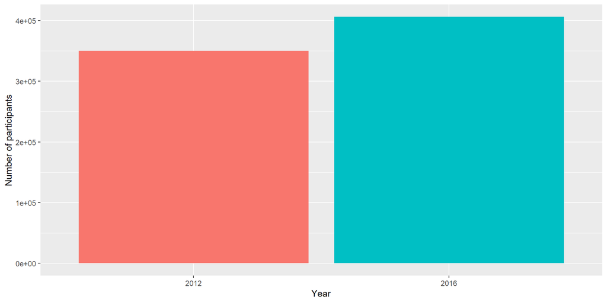

```r
ggplot() +
  geom_col(
    mapping = aes(
      x = factor(year),
      y = n,
      fill = factor(year)
    ),
    data = gezondheidsmonitor.participants.by.year,
    show.legend = FALSE
  ) +
  labs(
    x = "Year",
    y = "Number of participants"
  )
```

## Sex

Let’s check, per year, what the number and percentages of males and females is.

```r
gezondheidsmonitor.prevalence.by.year.and.sex <- gezondheidsmonitor.data %>%
  count(year, sex) %>%
  group_by(year) %>%
  mutate(
    prevalence = n / sum(n)
  ) %>%
  ungroup()
gezondheidsmonitor.prevalence.by.year.and.sex
```

| year | sex | n | prevalence |
| --- | --- | --- | --- |
| 2012 | M | 160225 | 0.4575687 |
| 2012 | F | 189941 | 0.5424313 |
| 2016 | M | 187928 | 0.4628689 |
| 2016 | F | 218079 | 0.5371311 |

We can visualise this in a plot.

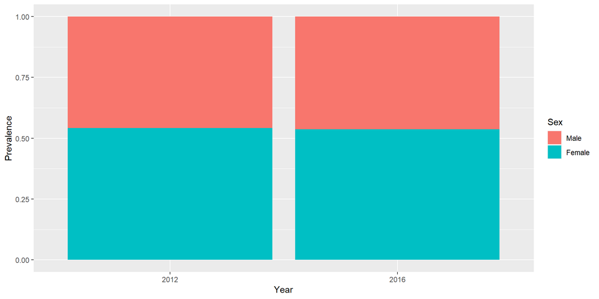

```r
ggplot() +
  geom_col(
    mapping = aes(
      x = factor(year),
      y = prevalence,
      fill = sex
    ),
    data = gezondheidsmonitor.prevalence.by.year.and.sex
  ) +
  labs(
    x = "Year",
    y = "Prevalence"
  ) +
  scale_fill_discrete(
    name = "Sex",
    label = c("M" = "Male", "F" = "Female")
  )
```

## Education

Let’s check, per year, what the number and percentages of each of the three levels of education is.

```r
gezondheidsmonitor.prevalence.by.year.and.education <- gezondheidsmonitor.data %>%
  count(year, education) %>%
  group_by(year) %>%
  mutate(
    prevalence = n / sum(n)
  ) %>%
  ungroup()
gezondheidsmonitor.prevalence.by.year.and.education
```

| year | education | n | prevalence |
| --- | --- | --- | --- |
| 2012 | L | 156041 | 0.4456201 |
| 2012 | M | 99302 | 0.2835855 |
| 2012 | H | 94823 | 0.2707944 |
| 2016 | L | 162522 | 0.4002936 |
| 2016 | M | 124654 | 0.3070243 |
| 2016 | H | 118831 | 0.2926821 |

We can visualise this in a plot.

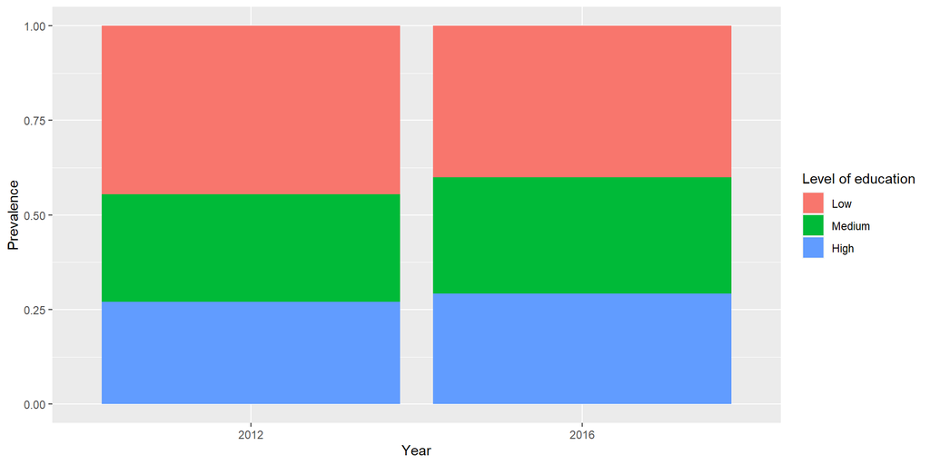

```r
ggplot() +
  geom_col(
    mapping = aes(
      x = factor(year),
      y = prevalence,
      fill = education
    ),
    data = gezondheidsmonitor.prevalence.by.year.and.education
  ) +
  labs(
    x = "Year",
    y = "Prevalence"
  ) +
  scale_fill_discrete(
    name = "Level of education",
    labels = c("L" = "Low", "M" = "Medium", "H" = "High")
  )
```

## Age

Let’s check, per year, what the minimum, mean and maximum age is.

```r
gezondheidsmonitor.data %>%
  group_by(year) %>%
  summarise(
    min.age = min(age),
    mean.age = mean(age),
    max.age = max(age),
    .groups = "drop"
  )
```

| year | min.age | mean.age | max.age |
| --- | --- | --- | --- |
| 2012 | 19.5 | 57.26013 | 107.5 |
| 2016 | 18.5 | 60.49603 | 107.5 |

We can visualise the age distribution in a boxplot.

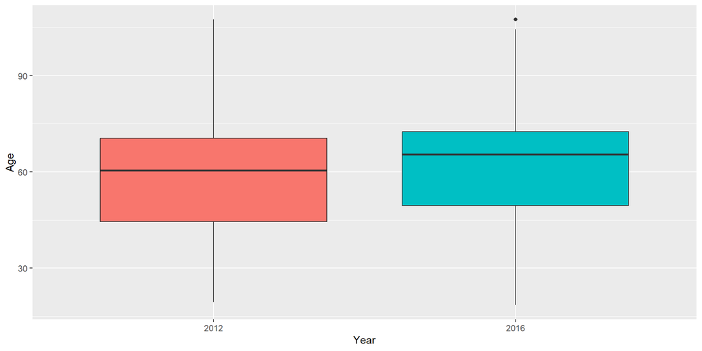

```r
ggplot() +
  geom_boxplot(
    mapping = aes(
      x = factor(year),
      y = age,
      fill = factor(year)
    ),
    data = gezondheidsmonitor.data,
    show.legend = FALSE
  ) +
  labs(
    x = "Year",
    y = "Age"
  )
```

We can also visualise the probability density of the age distribution by year.

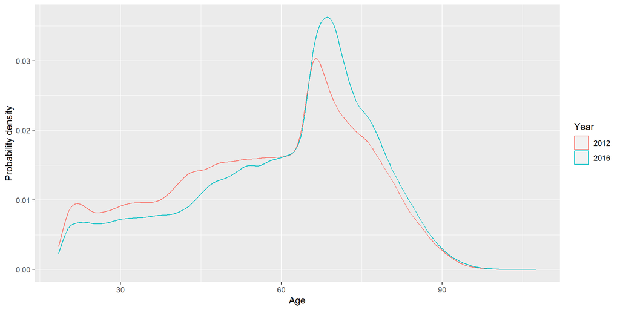

```r
ggplot() +
  geom_density(
    mapping = aes(
      x = age,
      col = factor(year)
    ),
    data = gezondheidsmonitor.data
  ) +
  labs(
    x = "Age",
    y = "Probability density",
    col = "Year"
  )
```

## BMI

Let’s check, per year, what the minimum, mean and maximum BMI value is.

```r
gezondheidsmonitor.data %>%
  group_by(year) %>%
  summarise(
    min.bmi = min(bmi),
    mean.bmi = mean(bmi),
    max.bmi = max(bmi),
    .groups = "drop"
  )
```

| year | min.bmi | mean.bmi | max.bmi |
| --- | --- | --- | --- |
| 2012 | 14.02141 | 25.72357 | 44.99927 |
| 2016 | 14.01000 | 25.93627 | 49.96000 |

We can visualise the BMI distribution in a boxplot.

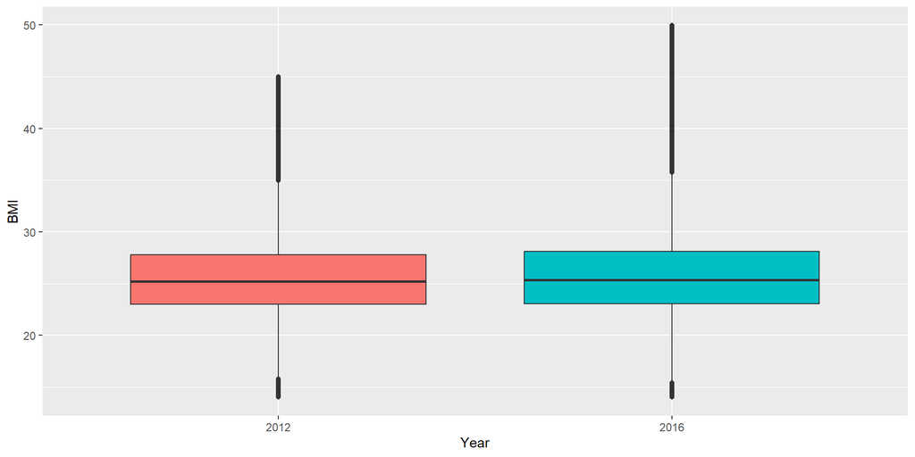

```r
ggplot() +
  geom_boxplot(
    mapping = aes(
      x = factor(year),
      y = bmi,
      fill = factor(year)
    ),
    data = gezondheidsmonitor.data,
    show.legend = FALSE
  ) +
  labs(
    x = "Year",
    y = "BMI"
  )
```

We can also visualise the probability density of the BMI distribution by year.

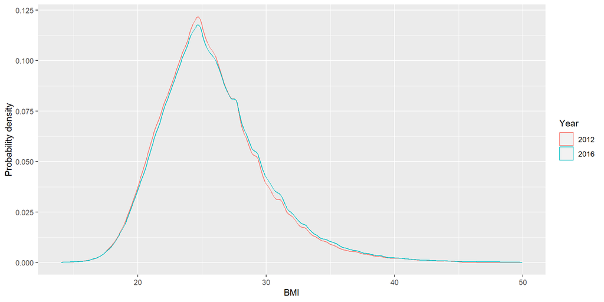

```r
ggplot() +
  geom_density(
    mapping = aes(
      x = bmi,
      colour = factor(year)
    ),
    data = gezondheidsmonitor.data
  ) +
  labs(
    x = "BMI",
    y = "Probability density",
    col = "Year"
  )
```

# Write Output

Finally, we write the cleaned data of the Gezondheidsmonitor to a CSV file.

```r
write_csv(
  x = gezondheidsmonitor.data,
  file = "../Output-Data/Gezondheidsmonitor.csv"
)
```

# References

GGD’en, CBS, and RIVM. 2012. “Gezondheidsmonitor Volwassenen 2012.” https://www.monitorgezondheid.nl/.

Huntington-Klein, Nick. 2021. *Vtable: Variable Table for Variable Documentation*. https://CRAN.R-project.org/package=vtable.

Wickham, Hadley, Mara Averick, Jennifer Bryan, Winston Chang, Lucy D’Agostino McGowan, Romain François, Garrett Grolemund, et al. 2019. “Welcome to the tidyverse.” *Journal of Open Source Software* 4 (43): 1686. https://doi.org/10.21105/joss.01686.

Wickham, Hadley, and Evan Miller. 2021. *Haven: Import and Export ’SPSS’, ’Stata’ and ’SAS’ Files*. https://CRAN.R-project.org/package=haven.